# Missing data and imputation II

Published

October 15, 2024

# Introduction

The aim of this lab is to learn more about ad-hoc imputation methods as well as multiple imputation, all using the `mice` package.

In this lab, we perform the following steps:

- Data processing.
- Inspection of the missingness pattern.
- Apply ad hoc imputation methods using the `mice` package.
- Apply multiple imputation using the `mice` package.
- Perform a linear regression and compare the output when different imputation approaches are used.

First, we load the packages required for this lab.

```r
library(tidyverse)
library(mice)
library(ggmice)
library(ISLR)
```

Before we start, set a seed for reproducibility, we use `123`, and also use `options(scipen = 999)` to suppress scientific notations, making it easier to compare and interpret results later in the session.

```r
set.seed(123)
options(scipen = 999)
```

# Data processing

For this part of the practical, you can directly copy and paste the code as given.

From the `ISLR` package, we will use the `College` dataset. Check out `help(College)` to find out more about this dataset. We will only use the following four variables:

- Outstate: Out-of-state tuition
- PhD: Pct. of faculty with Ph.D.’s
- Terminal: Pct. of faculty with terminal degree
- Expend: Instructional expenditure per student

Hence, we create a new data frame containing only these four variables:

```r
data_complete <-
  College |>
  select(Outstate, PhD, Terminal, Expend)

summary(data_complete)
```

```
    Outstate          PhD            Terminal         Expend
 Min.   : 2340   Min.   :  8.00   Min.   : 24.0   Min.   : 3186
 1st Qu.: 7320   1st Qu.: 62.00   1st Qu.: 71.0   1st Qu.: 6751
 Median : 9990   Median : 75.00   Median : 82.0   Median : 8377
 Mean   :10441   Mean   : 72.66   Mean   : 79.7   Mean   : 9660
 3rd Qu.:12925   3rd Qu.: 85.00   3rd Qu.: 92.0   3rd Qu.:10830
 Max.   :21700   Max.   :103.00   Max.   :100.0   Max.   :56233
```

During the practical, we focus on how different imputation approaches affect the linear relationship between `Outstate` and `Expend`. Therefore, we first inspect how this relationship looks like on the complete dataset.

```r
lm_complete <- lm(Expend ~ Outstate,
                  data = data_complete)

summary(lm_complete)
```

```
Call:
lm(formula = Expend ~ Outstate, data = data_complete)

Residuals:
   Min     1Q Median     3Q    Max
 -6131  -2022   -637   1027  39273

Coefficients:
             Estimate Std. Error t value            Pr(>|t|)
(Intercept) 542.86969  385.92915   1.407                0.16
Outstate      0.87325    0.03449  25.315 <0.0000000000000002 ***
---
Signif. codes:  0 '***' 0.001 '**' 0.01 '*' 0.05 '.' 0.1 ' ' 1

Residual standard error: 3866 on 775 degrees of freedom
Multiple R-squared:  0.4526,    Adjusted R-squared:  0.4519
F-statistic: 640.9 on 1 and 775 DF,  p-value: < 0.00000000000000022
```

We now generate missingness in the variables `Expend` and `Terminal` under a Seen Data-Dependent (SDD) mechanism, assuming that the missingness in these variables are dependent on the values of `Outstate` and `PhD` respectively.

```r
logistic <- function(x) (exp(x) / (1 + exp(x))) # logistic function

N <- nrow(data_complete) # number of observations

misprob_out <- logistic(scale(data_complete$Outstate)) # predictor Outstate
misprob_phd <- logistic(scale(data_complete$PhD)) # predictor PhD

data_missing <-
  data_complete |>
  mutate(
    R_out = 1 - rbinom(N, 1, misprob_out), # response indicator outstate
    R_phd = 1 - rbinom(N, 1, misprob_phd), # response indicator PhD
    m_Expend = ifelse(R_out == 0, NA, Expend),    # Missing in expend
    m_Terminal = ifelse(R_phd == 0, NA, Terminal) # and in terminal
  ) |>
  select(Outstate, m_Expend, m_Terminal) # Select variables that we will use
```

# Inspection of missingness

**1. Inspect the missingness pattern of the dataset using the function `plot_pattern()` from the `ggmice` package.**

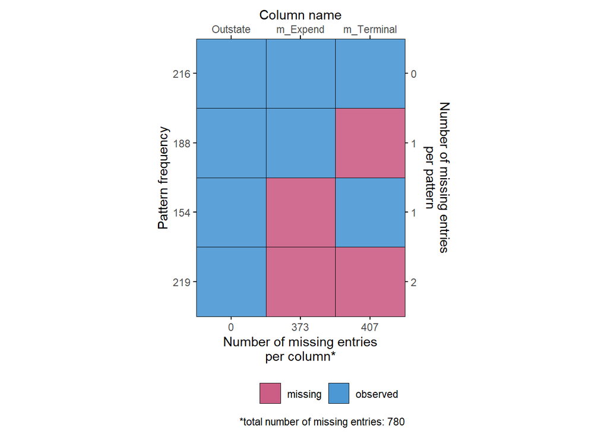

```r
plot_pattern(data_missing)
```

# Ad Hoc imputation methods

## Listwise deletion

**2. Create the object `lm_listwise` by fitting a regression model with `m_Expend` as the outcome object, predicted by `Outstate` using the data containing missing values.**

Hint: By default, `lm()` removes the observations that have missings on one of the variables in the model.

```r
lm_listwise <- lm(m_Expend ~ Outstate,
                  data = data_missing)
```

**3. Inspect the regression output by using the `summary()` function on the `lm_listwise` object. How many observations are excluded from this analysis? Is there a significant effect of `Outstate` on `m_Expend`?**

```r
summary(lm_listwise)
```

```
Call:
lm(formula = m_Expend ~ Outstate, data = data_missing)

Residuals:
    Min      1Q  Median      3Q     Max
-4986.2 -1490.9  -398.1   736.4 30053.4

Coefficients:
              Estimate Std. Error t value             Pr(>|t|)
(Intercept) 2006.74472  396.63965   5.059          0.000000641 ***
Outstate       0.70211    0.04153  16.904 < 0.0000000000000002 ***
---
Signif. codes:  0 '***' 0.001 '**' 0.01 '*' 0.05 '.' 0.1 ' ' 1

Residual standard error: 2758 on 402 degrees of freedom
  (373 observations deleted due to missingness)
Multiple R-squared:  0.4155,    Adjusted R-squared:  0.414
F-statistic: 285.8 on 1 and 402 DF,  p-value: < 0.00000000000000022
```

```r
# The coefficient is a bit smaller, the standard error somewhat larger, so we
# introduced some bias, and reduced the power. Both could have been expected,
# due to how we generated missings and since we lost 373 cases.
```

## Regression imputation

**4. Use `mice()` to impute `data_missing` with regression imputation (`method = "norm.predict"`), using a single imputation (`m = 1`), and a single iteration (`maxit = 1`), and name the output object `imp_regression`.**

NB: `m = 1` implies that only a single imputed data set is created, whereas `maxit = 1` implies that `mice()` does not iterate to converge to a distribution.

```r
imp_regression <- mice(
  data   = data_missing,
  method = "norm.predict",
  m      = 1,
  maxit  = 1
)
```

**5. Extract the complete data from the `mids` object using the `complete()` function, and confirm that you have a fully imputed dataset.**

```r
complete(imp_regression) |> # mice::complete() Takes an object of class mids,
  is.na() |>                # fills in the missing data, and returns the completed data in a specified format.
  sum()
```

```
[1] 0
```

The `with(data, expr)` function allows to fit `lm()` and `glm()` models with imputed data sets (`mids`-objects, to be precise), without requiring any further data handling. Check how the function works by running `?with.mids()`.

**6. Use the `with()` function to fit the regression model `lm(m_Expend ~ Outstate)` on the imputed data using the `imp_regression` as the data argument, and assign the output to an object called `lm_regression`.**

```r
lm_regression <- with(imp_regression, lm(m_Expend ~ Outstate))
```

**7. Inspect the results of the regression model. What happens to the regression coefficient and the corresponding standard error?**

```r
summary(lm_regression)
```

```
# A tibble: 2 × 6
  term        estimate std.error statistic   p.value  nobs
  <chr>          <dbl>     <dbl>     <dbl>     <dbl> <int>
1 (Intercept) 1989.     199.          9.97 4.05e- 22   777
2 Outstate       0.703    0.0178     39.5  1.44e-187   777
```

```r
# The regression coefficient is almost identical to the coefficient from the
# model with listwise deletion, which is not weird, because we used this
# relationship to impute the missing data. The standard error is substantially
# smaller though, because we treat the imputed values as the true values, and
# given that all are on the regression line, we are overly certain about the
# estimated regression coefficient.

# From an inferential statistics viewpoint, this approach would only be valid
# if we have definitive proof that the unobserved values would exactly conform
# to the observed data. If this assumption does not hold, `norm.predict`
# creates too little variation in our dataset and we can not trust the
# resulting standard errors and p-values.
```

**8. Use `ggmice()` to create a scatterplot that shows the relationship between `m_Expend` (on the `y`-axis) and `Outstate` (on the `x`-axis). What do you notice?**

Hint: `ggmice()` works much the same way as `ggplot()`, but accepts `mids` objects. Check `?ggmice` for help.

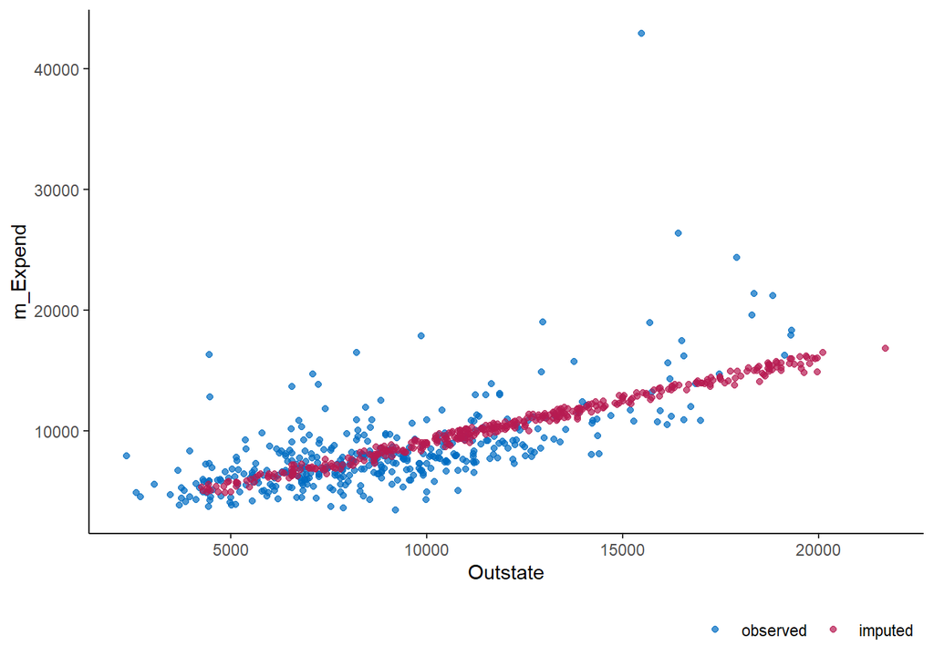

```r
imp_regression |>
  ggmice(aes(x = Outstate, y = m_Expend)) +
  geom_point()
```

```r
# Almost all imputed values are on a (almost) straight regression line (which
# is how we specified the imputation model). The variation around this line
# comes from the other variables that are also used in calculating the
# predictions.
```

## Stochastic regression imputation

We will now impute the missing data with stochastic regression imputation, adding an error term to the predicted values such that the imputations show variation around the regression line. The errors follow a normal distribution with a mean equal to zero and a variance equal to the residual variance.

**9. Impute `data_missing` with the stochastic regression method using `mice()` with `method = "norm.nob"`, again using a single imputation (`m = 1`) and a single iteration (`maxit = 1`) and assign the outcome to an object called `imp_stochastic`.**

```r
imp_stochastic <- mice(
  data   = data_missing,
  method = "norm.nob",
  m      = 1,
  maxit  = 1
)
```

**10. Fit the same regression model as before using the `with()` function, and assign the outcome to an object called `lm_stochastic`, and inspect the results of the fitted model using `summary()`. What do you notice?**

```r
lm_stochastic <- with(imp_stochastic, lm(m_Expend ~ Outstate))

summary(lm_stochastic)
```

```
# A tibble: 2 × 6
  term        estimate std.error statistic   p.value  nobs
  <chr>          <dbl>     <dbl>     <dbl>     <dbl> <int>
1 (Intercept) 1873.     287.          6.53 1.22e- 10   777
2 Outstate       0.715    0.0257     27.9  6.66e-119   777
```

```r
# When comparing the results after performing stochastic imputation with
# regression imputation, we see that the regression coefficient is still
# biased, but that the standard error has increased a little bit.
```

**11. Use `ggmice()` to create a scatterplot that shows the relationship between `m_Expend` (on the `y`-axis) and `Outstate` (on the `x`-axis) in the stochastic imputed data. What do you notice?**

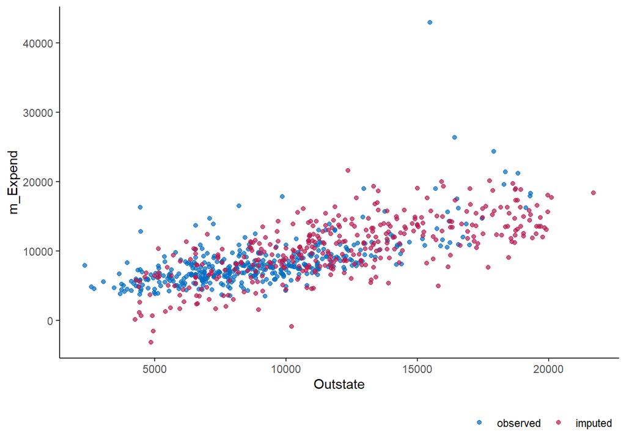

```r
imp_stochastic |>
  ggmice(aes(x = Outstate, y = m_Expend)) +
  geom_point()
```

```r
# There is considerably more variation between the imputed values as compared to
# the regression imputations. However, the current approach still treats the
# estimated regression coeffcients as fixed, although there is also uncertainty
# with respect to these coefficients. This uncertainty is still not taken into
# account with stochastic regression imputation.
```